# PSY 8712 Week 8 Project

Evan Knep

2024-03-17

# **Reproducible Image and Online Resources**

An image of this project as of *2024-03-17* can be accessed by [clicking this link](https://mybinder.org/v2/gh/evanknep/psy8712-week8/HEAD).

An interactive web app is available by [clicking this link](https://knepx001.shinyapps.io/shiny_week8/) instead.

# **Script Settings and Resources**

```r
setwd(dirname(rstudioapi::getActiveDocumentContext()$path))
library(tidyverse)
library(dplyr)
library(DT)
library(ggplot2)
```

# **Data Import and Cleaning**

Importing our dataset for preprocessing. Steps include reverse coding question q5 and converting our time columns into POSIX format.

```r
week8_tbl = read_csv("../data/week3.csv") %>% #initial data import
  mutate(q5 = 6 - q5) %>% #reverse coding our q5
  mutate(timeStart = as.POSIXct(timeStart)) %>% #converting our timestart and timeend columns to date time format
  mutate(timeEnd = as.POSIXct(timeEnd))
```

# **Visualization**

Presenting questionnaire scores in table format to allow access to raw scores, as well as a visualization of the relationship between questions 1-6 and and questions 8-10 via a correlation of the mean scores. Question 5 has been reverse scored.

|  | q1 | q2 | q3 | q4 | q5 | q6 |
| --- | --- | --- | --- | --- | --- | --- |
| 1 | 5 | 4 | 4 | 1 | 2 | 1 |
| 2 | 2 | 4 | 3 | 1 | 3 | 1 |
| 3 | 5 | 5 | 2 | 1 | 5 | 1 |
| 4 | 4 | 3 | 4 | 2 | 4 | 1 |
| 5 | 3 | 1 | 3 | 5 | 2 | 1 |
| 6 | 4 | 3 | 2 | 3 | 3 | 1 |
| 7 | 2 | 4 | 1 | 3 | 1 | 1 |
| 8 | 4 | 2 | 5 | 1 | 1 | 1 |
| 9 | 2 | 5 | 3 | 4 | 2 | 1 |
| 10 | 3 | 4 | 2 | 4 | 5 | 1 |

[output cut: 39 more lines]

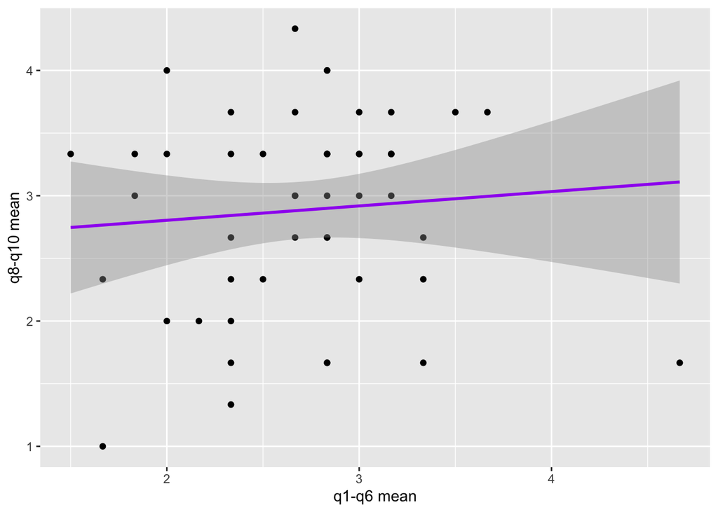

# **Analysis**

Observing the relationship between between responses to questions 1-6 and 8-10 by observing strength of correlation between the means of each batch of questions.

```r
mean_scores_tbl <- week8_tbl %>% # I realize rerunning this same code from above is probably not the correct answer, but when I attempt to save a new tibble with the mean values all in a single pipeline it also contains the plotting information so it gets a bit weird
  rowwise() %>%
  mutate(q1_q6_mean = mean(c_across(q1:q6), na.rm = TRUE),
         q8_q10_mean = mean(c_across(q8:q10), na.rm = TRUE))

corr_values = cor.test(mean_scores_tbl$q1_q6_mean, mean_scores_tbl$q8_q10_mean)
```

When comparing the mean values of responses to questions 1-6 and 8-10, I find a correlation of 0.0847457. Our p-value for this correlation is 0.5626235, which when combined with our correlation of near 0, suggests that mean responses of questions 1-6 and 8-10 are not correlated.

# **Data Export**

```r
mean_scores_tbl %>%
  select(-c(timeStart, condition, q1:q10)) %>%
  write_csv("../data/week8_shiny_data.csv")
```